# Cg -Pi time course analysis update

Bin He

created on 2022-11-15 (updated 2022-12-07)

```r
require(tidyverse)     ## for plotting
require(cowplot)       ## for some useful defaults in ggplot2
require(limma)         ## for differential gene expression analysis
require(edgeR)         ## for DGEList()
require(DESeq2)        ## for PCA plot
require(UpSetR)        ## for multi-set alternative to vennDiagram plots
require(rtracklayer)   ## for importing gtf files
#require(GGally)        ## for pairs plot
#require(tximport)      ## for importing Kallisto and Salmon counts
#require(Glimma)        ## for visually explore the results
#require(NMF)           ## for heatmap plot
#require(gplots)        ## for heatmap plot
#require(aroma.light)   ## for exploratory analysis
#source("../code/R_subfunctions_20171026.R")  ## custom defined functions
```

# Goal

1. Characterize the **genome-wide** transcriptional response to inorganic phosphate starvation in *C. glabrata*. Identify the core and auxiliary response genes.

   > previously I used RNAseq in *pho80∆* to identify genes induced by Pho4, while measuring Pho4 binding profile under physiological starvation conditions. This dataset will allow me to revisit some of the genes deemed bound but not induced by Pho4 in the previous dataset, to see if they are actually induced under starvation.
2. In addition to identifying the genes that respond to the starvation, but also their kinetics.

   > this is motivated by Barkai group’s Cell Reports study, where they showed that PHO genes in *S. cerevisiae* were induced in two big waves following starvation. I want to see if similar dynamics can be observed in *C. glabrata*
3. Compare both the gene lists and temporal pattern in *C. glabrata* with the equivalent data in *S. cerevisiae* (later in *K. lactis*).

# Experiment set up

In E009, I performed time-course transcriptome profiling following inorganic phosphate starvation in two genetic background, namely the wild-type and *pho4∆*. The purpose of doing this in *pho4∆* is to distinguish Pho4-dependent vs Pho4-independent gene induction. In the present analysis, I will focus on the wt dataset.

The time-course includes a pre-stress (rich media) condition and a series of post-stress time points. The sampling density on the time axis is denser in the beginning, then gradually becoming sparser, in contrast to the regular interval designed used in Barkai’s study. This is so that I can focus on the early time points while restricting the total number of samples I need to collect and process.

The sample sheet is documented here

Below is a simple chart to show the design:

| Genotype | Time point | Replicates | Comment |
| --- | --- | --- | --- |
| 80∆ | rich media | 2 | for consistency check with my previous data |
| 80∆ 4∆ | rich media | 2 | for consistency check with my previous data |
| wt-1 | pre, 20’, 30’, 45’, 60’, 90’, 120’, 150’, 180’, 240’ | 1 | time course for wt |
| 4∆-1 | pre, 20’, 30’, 45’, 60’, 90’, 120’, 150’, 180’, 240’ | 1 | time course for 4∆ |
| wt-2 | pre, 20’, 30’, 45’, 60’, 120’, 180’, 240’ | 1 | biol. repl. for wt-1 |
| 4∆-2 | pre, 20’, 30’, 45’, 60’, 120’, 180’ | 1 | biol. repl. for 4∆-1 |

```r
sample <- read_csv("../data/sample_sheet/Ex009_experiment_set_up_20171019.csv", col_types = cols())
sp <- sample %>% filter(Genotype == "wt") %>%
  mutate(group = gsub("m$", "", Timepoint) %>% fct_recode(`0` = "pre") %>% fct_relevel(c("0", "20", "30", "45", "60", "90", "120", "150", "180", "240", "del80"))) %>%
  select(Sample, group) %>%
  column_to_rownames(var = "Sample")
```

# Analysis notes

In this re-analysis, I made a few changes to the pipeline. First, I updated the genome reference to the latest long read-based assembly from the Cormack lab (downloaded from [NCBI assembly database](https://www.ncbi.nlm.nih.gov/assembly/GCA_014217725.1)). Because of the change in genome assembly and the corresponding annotation, it will take a bit of effort to compare the new set of read counts to the old one I obtained in 2017, using the CBS138 refseq assembly and genome annotation available with it.

Second, I followed a [Galaxy tutorial](https://training.galaxyproject.org/training-material/topics/transcriptomics/tutorials/ref-based/tutorial.html) to perform a number of quality controls on the raw fastq. The results were generally very good. See here for details.

1. `HISAT2` + `featureCounts`
2. `Kallisto`
3. `Salmon`

# Mapping-based pipeline

`HISAT2`->`featureCounts`->`LIMMA` or `EdgeR`

## Gene annotation and homology

Read and format the gene annotation file

```r
# feature table
anno <- read_tsv("../data/annotation/GCA_014217725.1_ASM1421772v1_feature_table.txt.gz", col_types = cols()) %>%
  filter(`# feature` %in% c("mRNA", "rRNA", "tRNA")) %>%
  select(chromosome, genomic_accession, start, end, strand, pid = related_accession, name, locus_tag, slen = feature_interval_length, attributes)

# to match the locus tags to the CAGL systematic IDs, we will import the GTF file, which contains the latter in the comment column
tag2id <- import("../data/annotation/GCA_014217725.1_ASM1421772v1_genomic.gtf.gz") %>%
  elementMetadata() %>% as_tibble() %>%
  filter(type == "transcript") %>%
  select(locus_tag, type = transcript_biotype, note) %>%
  separate(note, into = c("gid", "description", "comment"), sep = "~", fill = "right")
```

### Scer homologs for Cgla genes

*copied from `E036/01-Pi-timecourse`*

Mapping between the two species are downloaded from CGD. Two types of mappings are available: [orthology](http://www.candidagenome.org/download/homology/orthologs/) is based on the [Yeast Gene Order Browser](http://ygob.ucd.ie/); [best hits](http://www.candidagenome.org/download/homology/best_hits/) is based on `blastp` and is only performed for genes lacking a credible ortholog. Note that because both mappings start from *C. glabrata*, they are not the ideal mapping to use for identifying the *C. glabrata* ortholog for *S. cerevisiae* genes, but should be sufficient for the current purpose. This is because most of the genes do have 1-to-1 orthologs between the two species and thus starting from either species should yield the same mapping.

Below our goal is to identify the *S. cerevisiae* ortholog for each *C. glabrata* gene.

```r
# read the orthology map
cgToSc <- read_tsv("../data/annotation/C_glabrata_CBS138_S_cerevisiae_orthologs.txt", comment = "#",
                   col_names = c("CglaID","CglaName","Cgla.id","ScerID","ScerName","Scer.id"))
```

Add the Scer homolog name to the annotation object

```r
tag2id <- left_join(select(gtf, locus_tag, gid, description, type),
                    select(cgToSc.both, gid = CgladID, ScerID, ScerName), by = "gid")
```

[output not shown]

## Count data

```r
cts <- list()
cts$hisat2 <- read.delim("../data/gene_count/HISAT2-featureCounts-joined.tsv", row.names = "Geneid") %>% as.matrix()
colnames(cts$hisat2) <- gsub("\\.fastq\\.gz", "", colnames(cts$hisat2))
cts$hisat2 <- cts$hisat2[,rownames(sp)] # reorder the columns
head(cts$hisat2)
```

```
               S3   S4   S7   S8  S11  S12  S15  S16  S19  S20 S20prime  S23  S25  S26  S29  S31  S32
GWK60_A00011    0    0    0    0    0    0    0    0    0    0        0    0    0    0    0    0    0
GWK60_A00033    0    0    0    0    0    0    1    0    0    1        0    0    0    0    2    0    1
GWK60_A00055   47   61   39   31   92   63   60  114   94  123      139  252  205  445  318  392  300
GWK60_A00077  272  346  556  327  979  768  628 1046  774 1115     1370 1665  914 2409 1390 1505 1102
GWK60_A00099 1463 1875 2119 1421 2733 2548 1529 2359 1632 2187     2762 2849 1367 4090 2098 2178 1797
GWK60_A00121  320  407  410  260  528  479  359  588  307  409      489  614  301  736  397  500  329
              S35  S37  S38
GWK60_A00011    0    0    0
GWK60_A00033    0    0    0
GWK60_A00055  391  121   96
GWK60_A00077 1153  530  603
GWK60_A00099 1591 2837 3127
GWK60_A00121  719  634  718
```

Check to make sure the row and column metadata matches the row- and column names of the count matrix

```r
all(colnames(cts$hisat2) == rownames(sp))
```

```
[1] TRUE
```

```r
all(rownames(cts$hisat2) == tag2id$locus_tag)
```

```
[1] FALSE
```

```r
all(rownames(cts$hisat2) %in% tag2id$locus_tag)
```

```
[1] TRUE
```

The order of the gene names are different. We can fix that at the time of constructing the DGEList

```r
dh <- DGEList(counts = cts$hisat2,
              samples = sp,
              genes = tag2id[match(tag2id$locus_tag, rownames(cts$hisat2)),]) # the match() function ensures the gene order is the same
dh$samples
```

|  | group | lib.size | norm.factors |
| --- | --- | --- | --- |
| S3 | 0 | 4306544 | 1 |
| S4 | 0 | 5355750 | 1 |
| S7 | 20 | 5349795 | 1 |
| S8 | 20 | 3250653 | 1 |
| S11 | 30 | 6777990 | 1 |
| S12 | 30 | 5828267 | 1 |
| S15 | 45 | 4182929 | 1 |
| S16 | 45 | 6488273 | 1 |
| S19 | 60 | 4742766 | 1 |
| S20 | 60 | 6412154 | 1 |

[output cut: 10 more lines]

## Data pre-processing

### Library size normalization

Convert counts to counts per million (normalize by library size) and log counts per million. The latter will be used for exploratory analysis.

```r
hcpm <- cpm(dh); hlcpm <- cpm(dh, log = TRUE)
```

[output not shown]

*Reference*

[RUVSeq manual on Bioconductor](http://bioconductor.org/packages/release/bioc/vignettes/RUVSeq/inst/doc/RUVSeq.pdf)

```r
myPlotRLE <- function(x,...) {
  # this source code is copied from the EDASeq package (https://github.com/drisso/EDASeq/blob/master/R/methods-SeqExpressionSet.R)
  y <- log(x+1)
  median <- apply(y, 1, median)
  rle <- apply(y, 2, function(x) x - median)

  boxplot(rle, ...)
  abline(h=0, lty=2)
  invisible(rle)
}
```

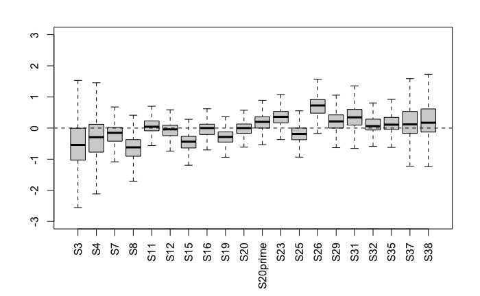

```r
myPlotRLE(cts$hisat2, outline=FALSE, ylim=c(-3, 3), las = 3)
```

Use count per million to normalize the library size

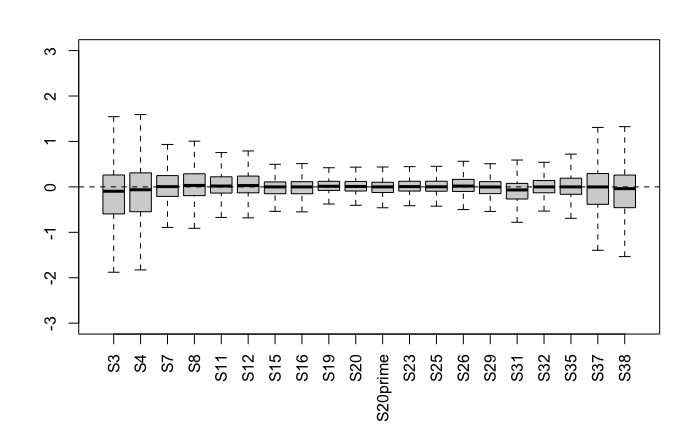

```r
dh <- calcNormFactors(dh)
cpm(dh, normalized.lib.sizes = FALSE, log = FALSE) %>%
  myPlotRLE(., outline=FALSE, ylim=c(-3, 3), las = 3)
```

Library size normalized data already look good (probably no significant compositional differences).

### Biological variability vs treatment

Examine variations between biological replicates and between different treatment (unstressed, time points)

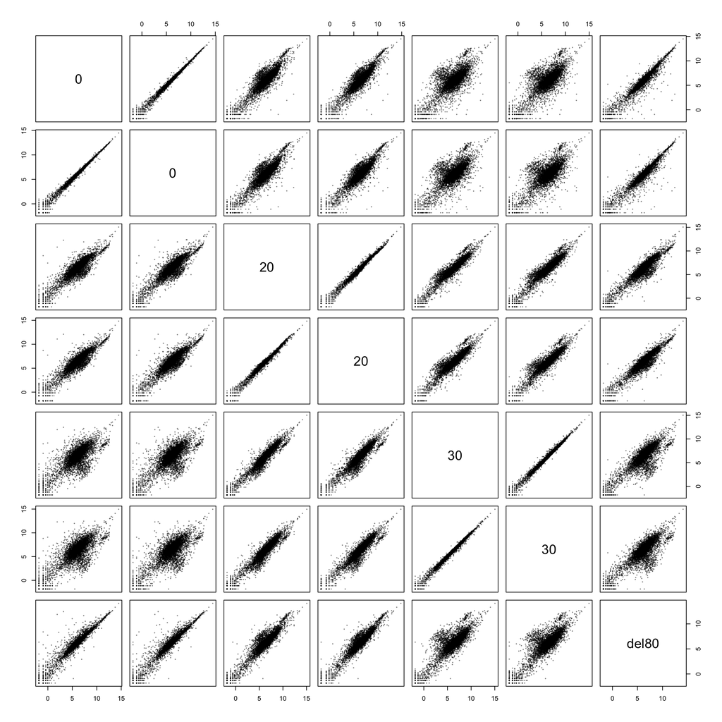

```r
tmp.list <- c("S3", "S4", "S7", "S8", "S11", "S12", "S37")
tmp.label <- as.character(sp[tmp.list, "group"])
pairs(hlcpm[,tmp.list], labels = tmp.label, cex = 0.4, col = alpha(1, 0.5), pch = 16)
```

```r
#as_tibble(hlcpm[,tmp.list]) %>%
#  rename_with(~ paste(as.character(sp[tmp.list, "group"]), .x, sep = "_")) %>%
#  GGally::ggpairs(.,lower = list(continuous = wrap("points", alpha = 0.3, size = 0.1)), progress = FALSE) +
#  theme_bw(base_size = 12) + background_grid(major = "none", minor = "none")
```

Biological replicates are highly correlated. A large number of genes in the middle (of log scale) are DE.

### Remove lowly expressed genes

Number of genes with less than ten counts in all samples

```r
table(rowSums(dh$counts<=10) == 20)
```

```
FALSE  TRUE
 5111   370
```

Filter genes using the `EdgeR` package

```r
keep.exprs <- filterByExpr(dh)
summary(keep.exprs)
```

```
   Mode   FALSE    TRUE
logical     375    5106
```

```r
f.dh <- dh[keep.exprs, keep.lib.sizes = FALSE]
```

Very few genes would have been removed. Probably OK to skip this step.

Plot the log cpm distribution before and after the filtering, following https://master.bioconductor.org/packages/release/workflows/vignettes/RNAseq123/inst/doc/limmaWorkflow.html

```r
L <- mean(dh$samples$lib.size) * 1e-6
M <- median(dh$samples$lib.size) * 1e-6
lcpm.cutoff <- log2(10/M + 2/L)
```

```r
nsamples <- ncol(dh)
col <- viridis::viridis(nsamples)
par(mfrow=c(1,2))
plot(density(hlcpm[,1]), col=col[1], lwd=2, ylim=c(0,0.28), las=2, main="", xlab="")
title(main="A. Raw data", xlab="Log-cpm")
```

```r
abline(v=lcpm.cutoff, lty=3)
for (i in 2:nsamples){
  den <- density(hlcpm[,i])
  lines(den$x, den$y, col=col[i], lwd=2)
}
```

```r
legend("topright", colnames(dh), text.col=col, bty="n", cex = 0.7)
f.hlcpm <- cpm(f.dh, log=TRUE)
plot(density(f.hlcpm[,1]), col=col[1], lwd=2, ylim=c(0,0.28), las=2, main="", xlab="")
```

```r
title(main="B. Filtered data", xlab="Log-cpm")
abline(v=lcpm.cutoff, lty=3)
```

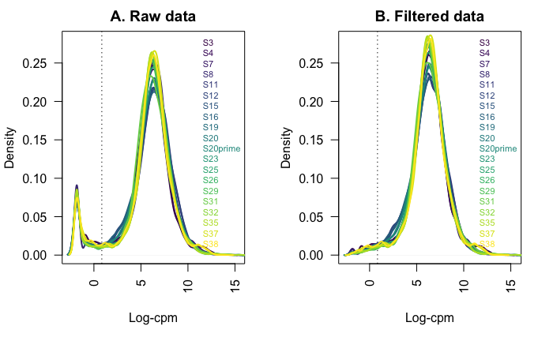

```r
for (i in 2:nsamples){
  den <- density(f.hlcpm[,i])
  lines(den$x, den$y, col=col[i], lwd=2)
}
legend("topright", colnames(f.dh), text.col=col, bty="n", cex = 0.7)
```

Genes that are not expressed are removed here.

### Normalizing gene expression distributions

Distributions of log-CPM values are similar throughout the experiment (shown above). Normalization by TMM is optional but shouldn’t hurt. I expect the calculated scaling factors to be very similar across the samples

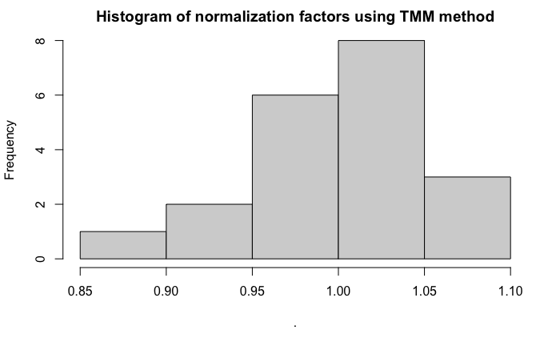

```r
f.dh <- calcNormFactors(f.dh, method = "TMM")
f.dh$samples$norm.factors %>% hist(main = "Histogram of normalization factors using TMM method")
```

## Exploratory analysis

### Unsupervised clustering using MDS

```r
par(mfrow=c(1,2))
col.group <- f.dh$samples$group
levels(col.group) <-  viridis::inferno(nlevels(col.group), end = 0.8)
col.group <- as.character(col.group)
plotMDS(f.hlcpm, labels=f.dh$samples$group, col=col.group)
title(main="A. First two dimensions")
```

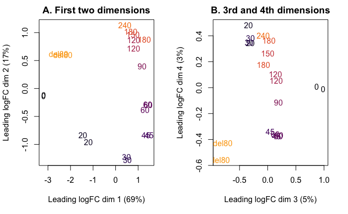

```r
plotMDS(f.hlcpm, labels=f.dh$samples$group, col=col.group, dim=c(3,4))
title(main="B. 3rd and 4th dimensions")
```

**Discussion**

The first dimension separates the samples into ~3 groups: [del80 and 0’], [20’], [30’-240’]. Within the last group, the [45’-90’] samples appear to be slightly more advanced than the remaining ones. My interpretation of this pattern is that

1. the fact that del80 groups with pre-stress suggests that the genes driving this dimension are not the PHO genes (since those genes should be turned on in *pho80∆*). These are likely to be growth genes, e.g., ribosomal genes being down regulated, and general stress genes being induced.
2. 20’ represents a clear intermediate time point, suggesting most of the genes behind this dimension reached peak or bottom by 30’
3. the slight separation of the 45’-90’ time points from the other 30’+ ones may be indicating a sizable group of the genes behind this dimension reached their top/bottom values during the 45’-90’ period, but not by much compared with 30’. there is probably a slight drop (or rise) towards the baseline after 90’.

The second dimension separates the early time points (20’-60’) and the late time points (90’-240’). The pre-stress sample grouped is closer to the first than to the second group, while the `del80` sample is closer to the second group. The meaning of this is unclear to me right now.

First, we will construct a data object

```r
dds <- DESeqDataSetFromMatrix(countData = cts$hisat2,
                              colData = sp,
                              design = ~ group)
mcols(dds) <- DataFrame(mcols(dds), tag2id[match(tag2id$locus_tag, rownames(cts$hisat2)),])
mcols(dds)
```

```
DataFrame with 5481 rows and 6 columns
                locus_tag          gid            description        type      ScerID    ScerName
              <character>  <character>            <character> <character> <character> <character>
GWK60_A00011 GWK60_A00011 CAGL0A00099g Putative adhesin-lik..        mRNA          NA          NA
GWK60_A00033 GWK60_A00033 CAGL0A00143g Putative adhesin-lik..        mRNA          NA          NA
GWK60_A00055 GWK60_A00055 CAGL0A00165g Protein of unknown f..        mRNA          NA          NA
GWK60_A00077 GWK60_A00077 CAGL0A00187g Ortholog(s) have mit..        mRNA     YGL023C        PIB2
GWK60_A00099 GWK60_A00099 CAGL0A00209g Ortholog(s) have dol..        mRNA     YGL022W        STT3
...                   ...          ...                    ...         ...         ...         ...
GWK60_M14509 GWK60_M14509 CAGL0M14208r                     NA        rRNA          NA          NA
GWK60_M14531 GWK60_M14531 CAGL0M14211r                     NA        rRNA          NA          NA
GWK60_M14553 GWK60_M14553 CAGL0M14214r                     NA        rRNA          NA          NA
GWK60_M14575 GWK60_M14575 CAGL0M14217r                     NA        rRNA          NA          NA
GWK60_M14597 GWK60_M14597 CAGL0M14300g Putative adhesin-lik..        mRNA          NA          NA
```

Estimate the size factors and disperions

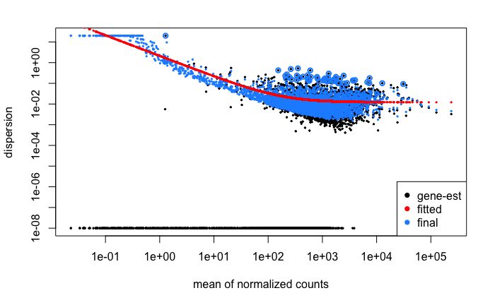

```r
dds <- estimateSizeFactors(dds)
dds <- estimateDispersions(dds)
plotDispEsts(dds)
```

Next, we can conduct a PCA analysis

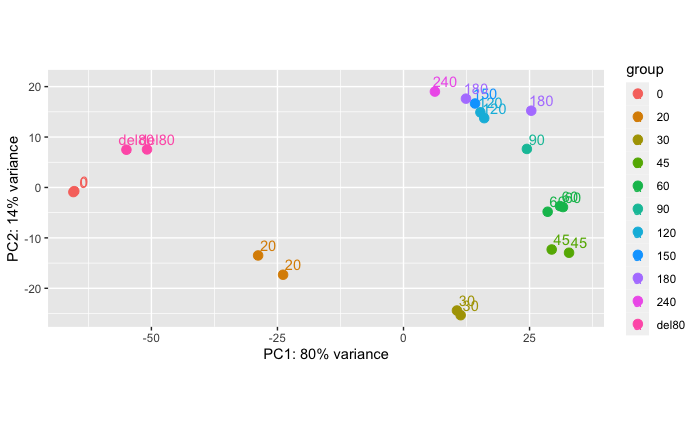

```r
rld <- rlog(dds, blind = FALSE)
plotPCA(rld, intgroup = "group") +
  geom_text(aes(color = group, label = group), nudge_x = 2, nudge_y = 2)
```

The result is highly similar to the MDS plot above. Note that the `DESeq2` objects created above will be used later to test an alternative DEG workflow.

Further check the sample correlations

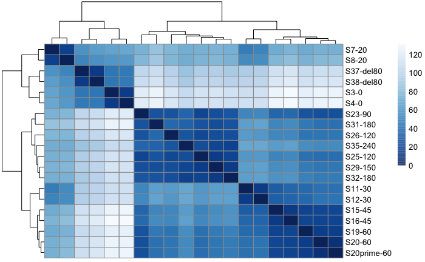

```r
require(pheatmap)
require(RColorBrewer)
sampleDists <- dist(t(assay(rld)))
sampleDistMatrix <- as.matrix(sampleDists)
rownames(sampleDistMatrix) <- paste(colnames(rld), rld$group, sep = "-")
colnames(sampleDistMatrix) <- NULL
colors <- colorRampPalette( rev(brewer.pal(9, "Blues")) )(255)
pheatmap(sampleDistMatrix,
         clustering_distance_rows=sampleDists,
         clustering_distance_cols=sampleDists,
         col=colors)
```

From this correlation structure, we should probably combine 45’ and 60’, then 90’-240’

## Clustering gene expression patterns

The goal is to 1) identify the genes whose expression changed significantly over a certain threshold and 2) cluster those genes based on their expression pattern (dynamics). Note that as we can see from the plots above, there are 4 effective time points: 20’, 30’, 45’-60’, 90’-240’. Combining the groups that don’t show strong differences could increase the power to detect DGEs.

An alternative to working with all the time points at once is to do pairwise comparisons to identify the early (20’), early-middle (30’), middle (45’-60’) and late (90’-240’) genes. We can then examine their overlaps and perform independent downstream analyses.

We will implement the first approach first.

To remove genes that don’t respond to the stimulus in meaningful ways, one way is to identify genes that significantly changed their expression by some threshold in at least one time point. We can achieve this using a F-test on a linear or generalized linear model: - using limma-trend or limma-voom and perform the F-test for all time points compared with 0’ - using EdgeR or DESeq2’s GLM framework to perform the same test - in either case, further filter the gene list by log2FC - with the resulting gene list, consider clustering or GO term / molecular pathway analysis

An alternative, as recommended by Limma or EdgeR, is to use a spline with n degrees of freedom (n < # of time points). This is useful when there are many (effective time points) and the response variable (gene expression) changes continuously. In our case, this may not be necessary.

Based on the results above, I will recode the groups of the samples into 0’, 20’, 30’, 45-60’ and 90-240’. We will exclude the `del80` group as it is not part of the time course.

```r
# f.dhx: filtered
f.dhx <- f.dh[,f.dh$samples$group != "del80"]
#f.dhx$samples$group <- fct_reorder(f.dhx$samples$group, as.integer(as.character(f.dhx$samples$group)))
f.dhx <- calcNormFactors(f.dhx, method = "TMM")
```

### LIMMA-voom

#### Testing

```r
design <- model.matrix(~group, data = f.dhx$samples)
colnames(design) <- gsub("group", "", colnames(design))
design
```

```
         (Intercept) t20 t30 t60 t90
S3                 1   0   0   0   0
S4                 1   0   0   0   0
S7                 1   1   0   0   0
S8                 1   1   0   0   0
S11                1   0   1   0   0
S12                1   0   1   0   0
S15                1   0   0   1   0
S16                1   0   0   1   0
S19                1   0   0   1   0
S20                1   0   0   1   0
S20prime           1   0   0   1   0
S23                1   0   0   0   1
S25                1   0   0   0   1
S26                1   0   0   0   1
S29                1   0   0   0   1
S31                1   0   0   0   1
S32                1   0   0   0   1
S35                1   0   0   0   1
attr(,"assign")
[1] 0 1 1 1 1
attr(,"contrasts")
attr(,"contrasts")$group
[1] "contr.treatment"
```

Remove heteroscedascity from count data

```r
par(mfrow = c(1,2))
f.dhv <- voom(f.dhx, design, plot=TRUE)
f.dhv
```

```
An object of class "EList"
$genes
```

|  | locus_tag | gid | description | type | ScerID | ScerName |
| --- | --- | --- | --- | --- | --- | --- |
| GWK60_A00055 | GWK60_A00055 | CAGL0A00165g | Protein of unknown function | mRNA | NA | NA |
| GWK60_A00077 | GWK60_A00077 | CAGL0A00187g | Ortholog(s) have mitochondrion localization | mRNA | YGL023C | PIB2 |
| GWK60_A00099 | GWK60_A00099 | CAGL0A00209g | Ortholog(s) have dolichyl-diphosphooligosaccharide-protein glycotransferase activity, role in protein N-linked glycosylation and oligosaccharyltransferase complex, plasma membrane localization | mRNA | YGL022W | STT3 |
| GWK60_A00121 | GWK60_A00121 | CAGL0A00231g | Ortholog(s) have protein kinase activity and role in protein phosphorylation | mRNA | YGL021W | ALK1 |
| GWK60_A00143 | GWK60_A00143 | CAGL0A00253g | Ortholog(s) have protein membrane anchor activity, role in protein insertion into ER membrane, retrograde vesicle-mediated transport, Golgi to ER and GET complex, mitochondrion localization | mRNA | YGL020C | GET1 |

```
5101 more rows ...

$targets
```

|  | group | lib.size | norm.factors | time |
| --- | --- | --- | --- | --- |
| S3 | t0 | 3844837 | 0.8928234 | 0 |
| S4 | t0 | 4982027 | 0.9302563 | 0 |
| S7 | t20 | 5581873 | 1.0434162 | 20 |
| S8 | t20 | 3510529 | 1.0799806 | 20 |
| S11 | t30 | 7180601 | 1.0594361 | 30 |

```
13 more rows ...

$E
                   S3       S4       S7       S8      S11      S12      S15      S16      S19      S20
GWK60_A00055 3.626933 3.625781 2.823031 3.165591 3.687277 3.340246 3.856132 4.153459 4.278390 4.243692
GWK60_A00077 6.147190 6.119978 6.639488 6.543662 7.091797 6.937462 7.233038 7.345612 7.313269 7.418800
GWK60_A00099 8.572284 8.556326 8.568759 8.661510 8.572429 8.666994 8.516113 8.518521 8.389014 8.390392
GWK60_A00121 6.381258 6.353923 6.200489 6.213451 6.201655 6.256948 6.427117 6.515154 5.980590 5.973045
GWK60_A00143 6.894705 7.108483 7.185475 7.090686 7.228028 7.388421 7.195835 7.267724 7.230861 7.211951
             S20prime      S23      S25      S26      S29      S31      S32      S35
GWK60_A00055 4.098845 4.678294 5.251347 4.971398 5.245275 5.328076 5.364183 5.676923
GWK60_A00077 7.395211 7.399895 7.405192 7.406634 7.371513 7.267554 7.239524 7.235857
GWK60_A00099 8.406483 8.174648 7.985678 8.170178 7.965268 7.800646 7.944738 7.700226
GWK60_A00121 5.909889 5.961424 5.804367 5.696658 5.564936 5.678753 5.497096 6.554905
GWK60_A00143 7.246771 7.239736 7.055188 7.189969 7.010276 6.942148 7.046599 6.924365
5101 more rows ...

$weights
          [,1]      [,2]      [,3]      [,4]     [,5]     [,6]     [,7]     [,8]     [,9]    [,10]    [,11]
[1,]  8.157944  9.904353  7.766362  5.498358 12.11422 11.04593 11.19221 14.98053 12.40806 15.11893 17.81216
[2,] 30.487692 37.657951 47.634824 36.793877 50.54876 50.92172 50.24911 49.49589 50.87456 49.36055 46.08263
[3,] 44.539191 40.639356 38.453010 45.431484 34.89884 36.74394 44.54353 38.11076 42.19695 37.92168 34.84795
[4,] 34.954750 41.939304 41.998419 29.442938 47.64729 45.08158 33.33979 44.62472 37.56132 44.90449 48.82616
[5,] 46.091127 49.821729 50.866864 46.171728 48.36185 50.00233 49.63133 50.29564 50.70703 50.15757 47.29410
        [,12]    [,13]    [,14]    [,15]    [,16]    [,17]    [,18]
[1,] 38.92499 23.62131 47.31407 34.49507 38.67177 30.61671 31.91801
[2,] 43.16219 50.82640 37.80823 45.69587 43.30346 47.87344 47.16715
[3,] 36.77552 45.77655 32.05824 39.09757 36.90576 41.16573 40.45578
[4,] 48.24032 33.89476 50.90610 45.30182 48.08404 42.03172 43.25534
[5,] 46.15116 50.60508 40.58640 48.61491 46.29725 50.23000 49.73048
5101 more rows ...

$design
    (Intercept) t20 t30 t60 t90
S3            1   0   0   0   0
S4            1   0   0   0   0
S7            1   1   0   0   0
S8            1   1   0   0   0
S11           1   0   1   0   0
13 more rows ...
```

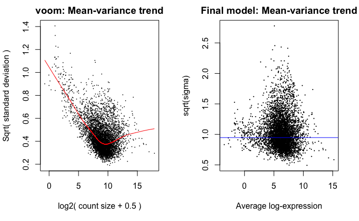

```r
vfit <- lmFit(f.dhv, design)
#vfit <- contrasts.fit(vfit, contrasts=contr.matrix)
efit <- eBayes(vfit)
plotSA(efit, main="Final model: Mean-variance trend")
```

The `eBayes()` function uses an empirical Bayes procedure to calculate a moderated t-statistics and the corresponding p-values

```r
names(efit)
```

```
 [1] "coefficients"     "stdev.unscaled"   "sigma"            "df.residual"      "cov.coefficients"
 [6] "pivot"            "rank"             "genes"            "Amean"            "method"
[11] "design"           "df.prior"         "s2.prior"         "var.prior"        "proportion"
[16] "s2.post"          "t"                "df.total"         "p.value"          "lods"
[21] "F"                "F.p.value"
```

Identify the subset of genes with significant DGE at any of the time points through the time course. This is done by calling `topTable()` on the `eBayes()` fitted object. One can either manually remove the intercept term using `efit[,-1]`, or use `coef = NULL`, in which case the function will calculate the F-statstics for all the coefficients combined except for the intercept (=expression level at 0’). This is equivalent to testing the fold change at all time points compared with 0’ and assessing the evidence for at least one of them being significant.

```r
topTable(efit[, -1], number = 20) %>% select(-locus_tag, -type, -ScerID)
```

|  | gid | description | ScerName | t20 | t30 | t60 | t90 | AveExpr | F | P.Value | adj.P.Val |
| --- | --- | --- | --- | --- | --- | --- | --- | --- | --- | --- | --- |
| GWK60_A01155 | CAGL0A01243g | Has domain(s) with predicted transmembrane transporter activity, role in transmembrane transport and integral component of membrane localization | GIT1 | 4.4545003 | 4.822938 | 5.133546 | 5.461387 | 12.002021 | 697.6004 | 3.118912e-18 | 1.592517e-14 |
| GWK60_K07359 | CAGL0K07546g | Putative phosphate starvation inducible acid phosphatase; contains a phosphomutase-like domain; functionally complements a S. cerevisiae pho5 mutant; transcript abundance during phosphate starvation r… | NA | 8.4835889 | 9.653601 | 10.114103 | 9.998297 | 11.099151 | 598.7362 | 1.096957e-17 | 2.246529e-14 |
| GWK60_H08811 | CAGL0H08844g | Putative adhesin-like protein | DDR48 | 2.7986015 | 4.331245 | 4.908765 | 4.978958 | 9.577463 | 585.4149 | 1.319935e-17 | 2.246529e-14 |
| GWK60_A01463 | CAGL0A01650g | Putative protein; gene is upregulated in azole-resistant strain | NA | 3.0325624 | 4.082907 | 4.553266 | 5.048714 | 9.375459 | 549.6482 | 2.216365e-17 | 2.829190e-14 |
| GWK60_D05269 | CAGL0D05082g | Protein of unknown function | UBI4 | 2.7363724 | 3.973337 | 3.982005 | 3.712079 | 10.221685 | 519.4677 | 3.525147e-17 | 3.599880e-14 |
| GWK60_G06677 | CAGL0G06952g | Ortholog(s) have inositol hexakisphosphate binding, polyphosphate kinase activity | VTC4 | 2.1561324 | 2.602760 | 2.729233 | 2.697967 | 9.408518 | 504.9939 | 4.446158e-17 | 3.783681e-14 |
| GWK60_J04081 | CAGL0J04268g | Ortholog(s) have acetate CoA-transferase activity, acetyl-CoA hydrolase activity, succinyl-CoA hydrolase activity, role in propionate metabolic process, methylcitrate cycle, response to acetate and gl… | ACH1 | 0.3682767 | 1.977951 | 2.874634 | 2.681758 | 9.259221 | 488.6601 | 5.824304e-17 | 4.248414e-14 |
| GWK60_C01925 | CAGL0C02321g | Ortholog(s) have lysophosphatidic acid phosphatase activity, nucleotidase activity and role in cellular response to phosphate starvation, nucleotide catabolic process, response to carbon starvation, t… | PHM8 | 2.6611239 | 3.465165 | 3.833937 | 4.094277 | 8.458968 | 373.9025 | 5.228950e-16 | 3.337378e-13 |
| GWK60_K04103 | CAGL0K04235g | Putative transaldolase | NQM1 | 1.0938990 | 1.938000 | 2.350704 | 2.845715 | 9.944471 | 355.8410 | 7.841609e-16 | 4.076000e-13 |
| GWK60_J06875 | CAGL0J07040g | Ortholog(s) have glycerophosphocholine phosphodiesterase activity, role in cellular response to drug, glycerophospholipid catabolic process and cytosol, ribosome localization | GDE1 | 2.4655952 | 2.787701 | 2.853833 | 2.810198 | 9.227573 | 352.4244 | 8.485664e-16 | 4.076000e-13 |

[output cut: 10 more lines]

How many genes show evidence of significant DGE in at least one time point?

```r
res.F.test <- topTable(efit[,-1], number = Inf, sort.by = "none")
with(res.F.test, table(sig = adj.P.Val < 0.01, lfc = ifelse(t60 > 1, "> 1", ifelse(t60 < -1, "< -1", "[-1,1]"))))
```

```
       lfc
sig     [-1,1] < -1  > 1
  FALSE    642   24   59
  TRUE    2106 1080 1195
```

We can see that many genes have relatively small fold changes at 60’ despite having significant P-values for the F-test. We could further filter for effect size to get at fewer genes for downstream analysis.

How does the F-test classification of gene compare with the individual time point results? The idea is to identify genes significant at each time point and examine their overlap among the time points and with the overall F-test result.

```r
res.t.test <- decideTests(efit[, -1], method = "separate", p.value = 0.05, lfc = 1)
all(rownames(res.t.test) == rownames(res.F.test))
```

```
[1] TRUE
```

```r
resAll <- cbind(F = with(res.F.test, (adj.P.Val < 0.05) * ifelse(t60 > 1, 1, ifelse(t60 < -1, -1, 0))),
                res.t.test[,c("t90", "t60", "t30", "t20")])
```

UpSet plot for the up-regulated genes

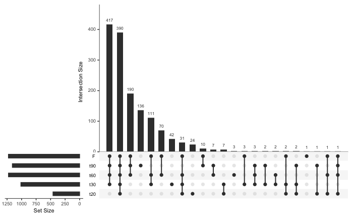

```r
# for reasons not completely clear to me, I have to convert the matrix above to
# to a data frame for the upset() function to work
upset(as.data.frame(resUp), order.by = "freq", keep.order = TRUE, sets = c("t20", "t30", "t60", "t90", "F"))
```

> the most frequent three classes represent those genes that are up-regulated more than 2 fold starting at 30’, 20’ or 60’ time points and stay on throughout the rest of the time course.
> 1. the fourth class is odd, representing genes whose expression only went up at 90’. worth looking into.
> 2. fifth and sixth classes represent genes that probably pass the threshold only at 30’+60’ or 60’ alone.
> 3. an eighth class represent 31 genes whose expression went up by 20’ but already dropped below the cutoff at 90’
> 4. the remaining classes contain very few genes.

UpSet plot for the down-regulated genes

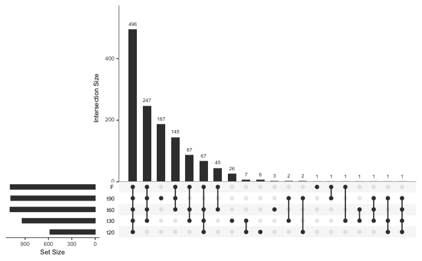

```r
# for reasons not completely clear to me, I have to convert the matrix above to
# to a data frame for the upset() function to work
upset(as.data.frame(resDn), order.by = "freq", keep.order = TRUE, sets = c("t20", "t30", "t60", "t90", "F"))
```

> the overall pattern is very similar to the up-regulated genes. differences include:
> 1. the most frequent class are the genes that are consistently down-regulated starting at 20’ and throughout the rest of the time course, followed by those that are down-regulated starting at 30’ and 60’.
> 2. the third class represents genes whose expression only went down at 90’. I start to suspect that these genes overlap with those that are up-regulated at earlier time points?
> 3. 5th-7th are similar to 1st, 2nd and 4th, except that 90’ time point wasn’t significant. the remaining classes contain very few genes.

Check the 90’ alone class

```r
as_tibble(resAll) %>% filter(t90 == 1, F != 1, t60 != 1) %>%
  dplyr::count(F, t90, t60, t30, t20) %>%
  select(n, t20, t30, t60, t90, F) %>%
  arrange(desc(n))
```

| n | t20 | t30 | t60 | t90 | F |
| --- | --- | --- | --- | --- | --- |
| 132 | 0 | 0 | 0 | 1 | 0 |
| 2 | -1 | -1 | -1 | 1 | -1 |
| 2 | -1 | -1 | 0 | 1 | 0 |
| 2 | 0 | 1 | 0 | 1 | 0 |
| 2 | 1 | 1 | 0 | 1 | 0 |
| 1 | 1 | 0 | 0 | 1 | 0 |

> my guess was wrong: the 132 genes that are induced at 90’ alone are not down-regulated at earlier time points. instead, this may represent a delayed response?

```r
as_tibble(resAll) %>% filter(t90 == -1, F != -1, t60 != -1) %>%
  dplyr::count(F, t90, t60, t30, t20) %>%
  select(n, t20, t30, t60, t90, F) %>%
  arrange(desc(n))
```

| n | t20 | t30 | t60 | t90 | F |
| --- | --- | --- | --- | --- | --- |
| 185 | 0 | 0 | 0 | -1 | 0 |
| 2 | 0 | -1 | 0 | -1 | 0 |
| 2 | -1 | 0 | 0 | -1 | 0 |
| 2 | 1 | 0 | 0 | -1 | 0 |
| 1 | -1 | -1 | 0 | -1 | 0 |

> similar for the 90’ down alone class.

Check some of the 90’-only genes

```r
geneList <- list()
geneList$`90up` <- names(which(rowSums(resAll) == 1 & resAll[,"t90"] == 1))
coef(efit)[geneList$`90up`,] %>% round(2) %>% head(10)
```

```
             (Intercept)   t20   t30  t60  t90
GWK60_A00055        3.63 -0.66 -0.10 0.51 1.56
GWK60_A02277        5.30  0.57  0.44 1.07 1.60
GWK60_A02673        4.79 -0.12  0.13 0.79 1.23
GWK60_A02739        4.63  0.38  0.73 0.93 1.13
GWK60_A02937        6.41  0.39  0.77 0.74 1.20
GWK60_A03465        0.88 -0.08  0.22 0.72 2.28
GWK60_B00693        5.58  0.42  0.86 0.92 1.20
GWK60_B01859        5.26  0.15  0.47 0.73 1.11
GWK60_B02673        7.39 -0.04  0.10 0.41 1.12
GWK60_B04521        3.90 -0.47  0.53 0.99 1.92
```

```r
geneList$`90dn` <- names(which(rowSums(resAll) == -1 & resAll[,"t90"] == -1))
coef(efit)[geneList$`90dn`,] %>% round(2) %>% head(10)
```

```
             (Intercept)   t20   t30   t60   t90
GWK60_A00319        8.50 -0.41 -0.60 -0.87 -1.25
GWK60_A01133        7.83  0.37  0.39  0.06 -2.88
GWK60_A01287        6.13 -0.15 -0.32 -0.74 -1.13
GWK60_A01947        6.16  0.21 -0.06 -0.73 -1.09
GWK60_A02035        8.22 -1.98  0.09  0.21 -1.81
GWK60_A03003        8.99  0.14  0.39 -0.64 -1.62
GWK60_A04455        7.68  0.06 -0.09 -0.53 -1.29
GWK60_B00297        0.25  0.48 -0.12  0.07 -2.05
GWK60_B01639        6.91  0.33  0.36  0.32 -1.09
GWK60_B03069        8.89 -0.26 -0.50 -0.72 -1.00
```

Looks like this group of genes are approaching significance at the earlier time point. So they seem to represent genuine late genes. The reason that the F-test was insignificant for them was not immediately clear to me.

#### Patterns of expression

Here we would like to visualize the expression dynamics for different groups of genes. We combined several time points in the testing procedure above. Here we would like to visualize the fine-grained time course. To do so, we will fit the linear model to the data using the complete design

```r
design2 <- model.matrix(~time, data = f.dhx$samples)
colnames(design2) <- gsub("time", "", colnames(design2))
design2
```

```
         (Intercept) 20 30 45 60 90 120 150 180 240
S3                 1  0  0  0  0  0   0   0   0   0
S4                 1  0  0  0  0  0   0   0   0   0
S7                 1  1  0  0  0  0   0   0   0   0
S8                 1  1  0  0  0  0   0   0   0   0
S11                1  0  1  0  0  0   0   0   0   0
S12                1  0  1  0  0  0   0   0   0   0
S15                1  0  0  1  0  0   0   0   0   0
S16                1  0  0  1  0  0   0   0   0   0
S19                1  0  0  0  1  0   0   0   0   0
S20                1  0  0  0  1  0   0   0   0   0
S20prime           1  0  0  0  1  0   0   0   0   0
S23                1  0  0  0  0  1   0   0   0   0
S25                1  0  0  0  0  0   1   0   0   0
S26                1  0  0  0  0  0   1   0   0   0
S29                1  0  0  0  0  0   0   1   0   0
S31                1  0  0  0  0  0   0   0   1   0
S32                1  0  0  0  0  0   0   0   1   0
S35                1  0  0  0  0  0   0   0   0   1
attr(,"assign")
 [1] 0 1 1 1 1 1 1 1 1 1
attr(,"contrasts")
attr(,"contrasts")$time
[1] "contr.treatment"
```

```r
# we are not conducting statistical test here. it's ok to use the same voom
# fitted object above
lfc <- lmFit(f.dhv, design2) %>% coef()
dat <- lfc[, -1]
```

Define gene sets

```r
all(gs$up$locus_tag == rownames(dat))
```

```
[1] TRUE
```

Plotting function

```r
myPlotSet <- function(dt, gs){
  # given a data set containing log2FC for the time points, and a list of
  # gene sets in the form of T/F for each gene as a vector or a list of vectors
  # produce a line plot visualizing the time course fold changes of all genes
  # in the set
  tb <- cbind(`0` = 0, dt[gs,]) %>%
    as_tibble(rownames = "locus_tag") %>%
    pivot_longer(!locus_tag, names_to = "time", values_to = "lfc") %>%
    mutate(time = as.integer(time))
  p <- ggplot(tb, aes(x = time, y = lfc)) +
    geom_line(aes(group = locus_tag), color = "steelblue", alpha = 0.6, linewidth = 0.5) +
    stat_summary(fun = "mean", geom = "line", color = "red4", linewidth = 1.5) +
    scale_x_continuous(minor_breaks = c(0, 20, 30, 45, 60, 90, 120, 150, 180, 240)) +
    labs(x = "Time (min)", y = "log2FC", title = paste(sum(gs), "genes", sep = " ")) +
    theme_cowplot() + background_grid(major = "none", minor = "x")
}
```

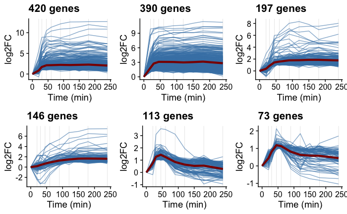

```r
pp <- lapply(select(gs$up, s_0111:s_0010), function(i) myPlotSet(dat, i))
plot_grid(plotlist = pp)
```

> 1. Groups 1-3 (top row) follow the same pattern, differing only in when they reach the peak.
> 2. Groups 4, while following the same pattern as 1-3, had a much slower rise, and should probably be considered separately in subsequent analyses
> 3. Groups 5 and 6 genes peak at around 45-60 minutes, then start to return to the baseline.

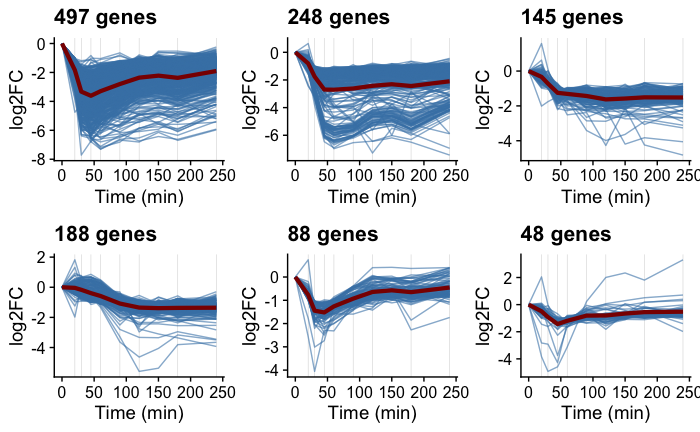

```r
pp <- lapply(select(gs$dn, s_1111:s_0010), function(i) myPlotSet(dat, i))
plot_grid(plotlist = pp)
```

> 1. Group 1, which contains the most genes in the down category, shows a distinct rapid down and recovery pattern.
> 2. Group 2 seems to consist of two subgroups (candidate for a K-means clustering with two clusters, or just based on maximum fold change, e.g., > 10 fold down. The recovery is not as prominent.
> 3. Group 3 and 4 goes down and stays down throughout the process. Clearly different from 1 and 2. Group 4 is milder than group 3.
> 4. Group 5 is similar to Group 1, but less drastic changes
> 5. Group 6 is not all that convincing. Could combine with some other groups in gene set analysis.

The next big questions are:

1. Do these different pattern groups enrich for particular functional groups of genes?
2. Where do the canonical PHO genes reside?

## Salmon

```r
files <- file.path("../output/read-count/salmon", paste0(rownames(sp), ".sf.gz"))
names(files) <- rownames(sp)
salmon <- tximport(files, type = "salmon", txOut = TRUE)
# convert gene names
tid2gid <- tibble(tid = rownames(salmon$counts)) %>%
  separate(tid, into = c("chr", "type", "pid", "index"), sep = "_")
```